# TESSERA: Tool for Estimating Spatial and Sample-level Effects via Regression Analysis

Florica Constantine

University of California, Berkeley

31 August 2026

#### Package

TESSERA 0.99.1

# 1 Introduction

`TESSERA` is a method for fitting multi-sample spatial generalized linear mixed models (GLMM). In this context, “multi-sample” refers to datasets comprising multiple distinct areas or regions, such as independent tissue slices, each characterized by its own unique spatial covariance structure and coordinate system.

## 1.1 Motivation: Spatial Transcriptomics

The development of `TESSERA` is driven by the rapid growth of spatial transcriptomics, where multi-sample or multi-tissue datasets are increasingly common. In this context, samples often consist of independent tissue slices with disparate coordinate systems, varying cell type distributions, and differing underlying tissue architectures.

These factors often preclude the use of traditional spatial methods that rely on the assumption of a single, continuous coordinate plane. `TESSERA` bridges this gap by allowing for sample-specific spatial modeling within a unified global cross-sample inference framework. This allows investigators to evaluate diverse biological questions via targeted differential expression hypotheses, both within and between samples. For more details on the underlying methodology, please see our `TESSERA` methodological manuscript (Constantine et al. 2026).

## 1.2 Limitations of Existing Methods

Traditional spatial statistical methods often rely on the assumption of a single, continuous coordinate plane. When applied to multi-sample studies, these frameworks typically break down because they cannot naturally bridge independent sample coordinates or accommodate experimental design hierarchies (e.g., nested technical or biological replicates across treatment groups). Investigators are frequently forced to either analyze samples in complete isolation—losing statistical power—or treat observations as spatially independent, which violates core assumptions and dramatically inflates False Discovery Rates (FDR).

# 2 Method

## 2.1 TESSERA Model

`TESSERA` fits an overdispersed Poisson GLMM. For an observation $j$ in sample $i$, the counts $Z_{i, j}$ are modeled as:
$$Z_{i, j} \sim \text{Pois}\left(C_{i, j} \exp\left(\boldsymbol{X}_{i, j}^\top \boldsymbol{\beta} + \phi_{i, j}\right) \right),$$
where

- $C_{i, j}$ is an offset (e.g., library size),
- $\boldsymbol{X}_{i, j}$ represents the covariates,
- $\boldsymbol{\beta}$ represents the fixed effects,
- $\phi_{i, j}$ represents the spatial random effects.

For each sample $i$, the spatial random effects follow:
$$\boldsymbol{\phi}_i \sim N(\mathbf{0}, \boldsymbol{\Sigma}_i),$$
where $\boldsymbol{\Sigma}_i$ is a sample-specific covariance matrix. This parameterization accounts for within-sample spatial autocorrelation while permitting different samples to have their own unique, independent spatial covariance structures.

A defining feature of `TESSERA` is its ability to estimate a **single set of fixed effects**, $\boldsymbol{\beta}$, across the entire dataset, even while permitting each individual sample to have its own independent spatial covariance structure. This provides a rigorous foundation for addressing differential expression across experimental conditions–such as comparing diseased vs. healthy tissue–while simultaneously accounting for the spatial autocorrelation inherent within each sample.

In the case of spatial transcriptomics, the GLMM is fit separately for each gene.

### 2.1.1 Flexible Design Formulations

Multi-sample spatial studies inherently involve hierarchical structures, with cells nested within tissue slices across cell types and experimental conditions. The design matrix $\boldsymbol{X}$ can be formulated to support complex designs. Some examples of possible covariates are:

- **Cell-Type-by-Condition Interactions:** Interaction terms between cell types and conditions allow baseline expression to be estimated separately for every cell-type-condition combination.
- **Sample-Level Variation:** Nested sample identifiers control for sample-specific baseline variation across conditions.
- **Cell- and Sample-Level Covariates:** Additional covariates, including patient demographics, disease stage, or cell-level phenotypic markers, can be incorporated directly to control for known sources of biological variation.

`TESSERA` requires the user to either input a pre-computed design matrix or pass in a design formula, analogous to standard `R` modeling functions like `stats::glm()`.

## 2.2 Supported Spatial Covariance Structures

`TESSERA` supports two primary classes of spatial covariance structures, categorized by how they handle spatial dependencies.

### 2.2.1 Lattice Models

These models are designed for data where spatial relationships are defined via measurement-to-measurement adjacency matrices. Supported structures include:

- Leroux
- Conditional Autoregressive (CAR)
- Simultaneous Autoregressive (SAR)

### 2.2.2 Sparse Nearest-Neighbor Gaussian Process

`TESSERA` uses the sparse nearest-neighbor Gaussian process (spNNGP) framework to model dependencies via a sparsified kernel matrix derived from pairwise distances between measurements. Supported kernel functions include:

- Matern (“Mat”)
- Exponential (“Exp”)
- Gaussian (“Gau”)
- Spherical (“Sph”)

### 2.2.3 Implementation Recommendations

Selecting the appropriate covariance model depends on the geometry of the dataset under consideration:

- **Grid-like or regularly-sampled data**: If adjacency can be clearly defined, we recommend the Leroux lattice model as generally the most robust choice given its flexible decomposition of spatial vs. non-spatial variance.
- **Irregularly-sampled data**: For data where measurements do not follow a strict grid and adjacency of measurements cannot be determined, the spNNGP model with either the Matern or Exponential kernel is recommended.

## 2.3 Model Fitting via the ECM Algorithm

Parameter estimation is carried out using an Expectation-Conditional-Maximization (ECM) algorithm, treating the spatial random effects $\boldsymbol{\phi}_i$ as latent variables. In the E-step, the algorithm evaluates the expected complete-data log-likelihood given the observed counts and current parameter estimates. In the subsequent CM steps, this expectation is sequentially maximized by updating the shared fixed effects $\boldsymbol{\beta}$ alongside the sample-specific spatial covariance parameters.

## 2.4 Hypothesis Testing and Empirical Null Distributions

With the Generalized Linear Mixed Model (GLMM) successfully fitted to the expression data, we can move from parameter estimation to statistical inference.

### 2.4.1 Linear Contrasts for Differential Expression

Once the fixed effects $\boldsymbol{\beta}$ are estimated, scientific questions are formulated as linear contrasts:
$$H_0: \boldsymbol{c}^\top \boldsymbol{\beta} = 0 \quad \text{versus} \quad H_1: \boldsymbol{c}^\top \boldsymbol{\beta} \neq 0,$$
where $\boldsymbol{c}$ is a user-defined contrast vector. This supports a wide variety of differential expression tests, such as:

- **Within-Cell-Type DE Between Conditions:** Testing condition differences within a specific cell type (e.g., $\beta_{\text{VSMC, DKD}} - \beta_{\text{VSMC, Control}} = 0$).
- **Between-Cell-Type DE:** Comparing expression profiles between distinct cell types, either within a specific condition or averaged across groups.

### 2.4.2 Empirical Null Distribution

In finite-sample settings, the true null distribution of the Wald test statistics for a GLMM is typically unknown. `TESSERA` addresses this by modeling the Wald statistics using a scaled, non-central $\chi_1^2$ distribution, where an empirical null distribution is computed by fitting thousands of parallelized per-gene models. This fitted null is then used to evaluate the observed Wald statistics and derive $p$-values for differential expression.

# 3 Package Design

`TESSERA` isolates data engineering from model fitting. For most standard workflows, the user only needs to interact with a few high-level functions and a unified data container.

## 3.1 Object Classes and Data Flow

The package revolves around a specialized class structure designed to seamlessly handle multi-sample groupings:

- **Input Integration:** `TESSERA` acts as a downstream companion to the Bioconductor ecosystem. It natively ingests `SpatialExperiment` objects, automatically unpacking coordinates, counts, and spatial metadata.
- **The `TESSERA_data` Container:** The main preprocessing function, `prep_data()`, compiles these inputs into a structured list object. For lattice models, it pre-computes matrix eigenvalues and neighborhood weights once across the entire tissue layout, caching these static matrices so they do not have to be re-calculated during gene-by-gene iteration.

## 3.2 Core Functions at a Glance

The table below outlines the primary functions encountered in a typical analysis pipeline, moving from exploratory adata nalysis to downstream statistical inference.

| Function | Step | Purpose | Primary Inputs | Primary Outputs |
| --- | --- | --- | --- | --- |
| `prep_data()` | **Data Prep** | Assembles inputs and pre-computes eigenvalues of spatial matrices. | Data matrix or `SpatialExperiment` object, design matrix, model type | `TESSERA_data` object |
| `TESSERA_lattice()` / `TESSERA_spNNGP()` | **Fitting** | Fits the overdispersed GLMM model for a single gene. | `TESSERA_data`, gene name, optimization specs | Fitted model list object (`TESSERA_out`) |
| `calc_Wald_statistics()` | **Inference** | Conducts Wald tests for a user-defined contrast matrix. | `TESSERA_out`, contrast matrix | Data frame of test statistics |
| `select_Wald_threshold()` | **Inference** | Sweeps over statistics to fit the empirical null distribution. | Vector of Wald statistics | Empirical null parameter list |
| `calc_scaled_noncentral_chi2_pvalues()` | **Inference** | Computes empirical $p$-values using the fitted empirical null distribution. | Vector of Wald statistics, empirical null parameters | Vector of empirical $p$-values |

# 4 Installation

Install the latest release version of `TESSERA` from [Bioconductor](https://bioconductor.org/packages/TESSERA) using the following code:

```r
if (!require("BiocManager", quietly = TRUE))
    install.packages("BiocManager")
BiocManager::install("TESSERA", dependencies = TRUE)
```

Alternatively, `TESSERA` can be installed from [GitHub](https://github.com/floricaconstantine/TESSERA):

```r
if (!require("remotes", quietly = TRUE))
    install.packages("remotes")
remotes::install_github("floricaconstantine/TESSERA", dependencies = TRUE)
```

## 4.1 Packages to run vignette

Note that `TESSERA` utilizes the `Imports` namespace specification for its dependencies rather than `Depends`. This means that while all required packages are loaded internally to ensure `TESSERA` functions run correctly, their functions are not automatically attached to the global environment. To use external functions directly in an `R` session, load the respective packages explicitly using `library()` or call them using the double-colon operator (e.g., `ggplot2::ggplot()`). For clarity, this vignette explicitly loads all external packages required for the workflow below.

```r
# TESSERA
library(TESSERA)

# Data Downloading
library(BiocFileCache)

# Data Structures
library(SummarizedExperiment)
library(SingleCellExperiment)
library(SpatialExperiment)

# Data Manipulation and Matrix Utilities
library(dplyr)
library(reshape2)
library(Matrix)
library(MatrixGenerics)

# Statistics
library(MASS)
library(fdrtool)

# Visualization
library(ggplot2)
```

# 5 Data Input & Exploration

## 5.1 Input Data Object

`TESSERA` accepts either Bioconductor `SpatialExperiment` objects or standard R matrices as input. In the absence of a `SpatialExperiment` object, input data may be provided as a numeric count matrix, a numeric matrix of spatial coordinates, and an accompanying metadata data frame.

For detailed specifications on these formats, please refer to the Pre-processing Data with `prep_data` section.

## 5.2 Load and Inspect Data

To keep the package lightweight while providing realistic, high-resolution spatial datasets, the data for this vignette are hosted externally. The following helper function uses `BiocFileCache` to download the necessary files from the `TESSERA_manuscript` repository and store them locally, ensuring that subsequent runs are fast and do not require an active internet connection.

```r
# Define helper function to grab data files from the TESSERA_manuscript repository
get_my_data <- function(file_name) {
  # Define the URL (using the /raw/ path to handle Git LFS redirects)
  base_url <- "https://github.com/floricaconstantine/TESSERA_manuscript/raw/main/data/vignette_data/"
  target_url <- paste0(base_url, file_name)

  # Initialize the cache (ask = FALSE prevents interactive prompts during build)
  bfc <- BiocFileCache(ask = FALSE)

  # Check if the file is already in the cache, if not, download it
  # bfcrpath returns the LOCAL path to the cached file
  local_path <- bfcrpath(bfc, target_url)

  # Read the RDS from the local cached path
  return(readRDS(local_path))
}
```

To demonstrate the workflow, we use a pre-processed kidney dataset (Abedini et al. 2024) stored as a `SpatialExperiment` object, which contains 12,511 genes across 37,143 cells. Each cell is associated with a specific sample, cell type, and disease condition. As detailed in the Construct Design Matrix section, these covariates define the design matrix used to test various differential expression hypotheses.

```r
# Load Data
spe <- get_my_data("kidney_data_spe.rds")
dim(spe)
```

```
> [1] 12511 37143
```

The dataset consists of 14 samples across three experimental conditions.

```r
# Column containing sample IDs
sample_col <- "orig.ident"
# Column containing disease condition
condition_col <- "Group"
# Column containing cell type
celltype_col <- "celltype"

as.data.frame(SummarizedExperiment::colData(spe)) %>%
  dplyr::distinct(dplyr::pick(dplyr::all_of(c(sample_col, condition_col)))) %>%
  dplyr::count(dplyr::pick(dplyr::all_of(condition_col)))
```

```
>     Group n
> 1 Control 3
> 2     DKD 6
> 3     HKD 5
```

```r
# Number of cells per sample
sort(table(SummarizedExperiment::colData(spe)[, sample_col]))
```

```
>
> HK2873_ST HK2770_ST HK2671_ST HK3035_ST HK2852_ST HK2871_ST HK2844_ST HK2877_ST
>      1411      1736      2013      2027      2262      2404      2445      2960
> HK2529_ST HK2874_ST HK3432_ST HK3444_ST HK3513_ST HK3437_ST
>      2970      3027      3028      3198      3759      3903
```

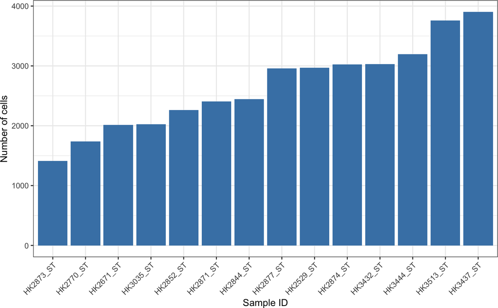

```r
# Convert table to a data frame
df_samp_counts <- as.data.frame(table(SummarizedExperiment::colData(spe)[, sample_col]))
colnames(df_samp_counts) <- c("sample", "count")

# Plot number of cells per sample
p <- ggplot2::ggplot(df_samp_counts, ggplot2::aes(x = reorder(sample, count), y = count))
p <- p + ggplot2::geom_bar(stat = "identity", fill = "steelblue")
p <- p + ggplot2::theme_bw()
p <- p + ggplot2::theme(axis.text.x = ggplot2::element_text(angle = 45, hjust = 1))
p <- p + ggplot2::labs(x = "Sample ID", y = "Number of cells")
p
```

We examine the number of cells per cell type across all samples and see that it varies widely.

```r
# Number of cells per cell type
sort(table(SummarizedExperiment::colData(spe)[, celltype_col]))
```

```
>
>                     RBC                Endo_Lym Dedifferentiated_Tubule
>                      24                      84                     221
>                   M_TAL                  Endo_G        Endo_Peritubular
>                     334                     359                     516
>                   PT_S2                    CD4T                     Mes
>                     545                     566                     614
>                    Podo                     DCT                     PEC
>                     643                     732                     820
>                     CNT           VSMC/Pericyte                    Mono
>                     879                     892                     939
>                      IC                     Mac                  MyoFib
>                     969                    1099                    1121
>            Plasma_Cells                      PC              GS_Stromal
>                    1501                    1601                    2243
>                   PT_S1                     iPT                     Fib
>                    2289                    2851                    3183
>                   PT_S3                   C_TAL
>                    3427                    8691
```

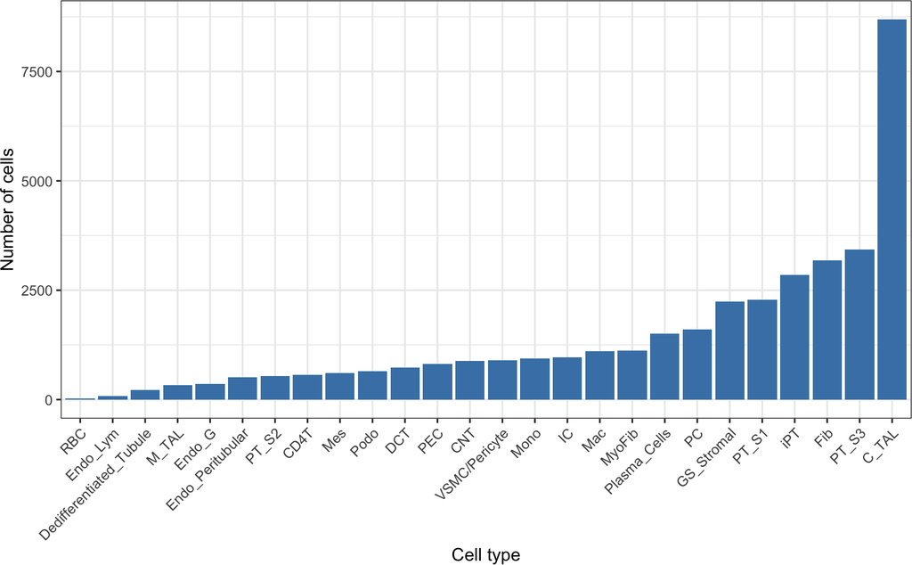

```r
# Convert table to a data frame
df_cty_counts <- as.data.frame(table(SummarizedExperiment::colData(spe)[, celltype_col]))
colnames(df_cty_counts) <- c("celltype", "count")

# Plot number of cells per sample
p <- ggplot2::ggplot(df_cty_counts, ggplot2::aes(x = reorder(celltype, count), y = count))
p <- p + ggplot2::geom_bar(stat = "identity", fill = "steelblue")
p <- p + ggplot2::theme_bw()
p <- p + ggplot2::theme(axis.text.x = ggplot2::element_text(angle = 45, hjust = 1))
p <- p + ggplot2::labs(x = "Cell type", y = "Number of cells")
p
```

For compatibility with standard visualization tools, we append the spatial coordinates directly to the metadata.

**Note**: It is essential for the row names of the coordinates in a ‘SpatialExperiment’ object to match the row names of the metadata and the column names of the count matrix; it is not necessary to add the coordinates to the metadata, but it is necessary for the row names to match.

```r
# Add the spatial coordinates into the metadata (convenience)
SummarizedExperiment::colData(spe) <- cbind(SummarizedExperiment::colData(spe),
                                            SpatialExperiment::spatialCoords(spe))
```

To focus our analysis on the most informative features (here, genes), we sort the genes by raw count variance. In a typical workflow, the data object is often subset to the top $G$ genes (e.g., the top 3,000 or 5,000 genes) prior to model fitting.

```r
# Calculate variance across all spots for each gene
rv <- MatrixGenerics::rowVars(SingleCellExperiment::counts(spe))
names(rv) <- rownames(spe)

# Order the entire object by raw count variance (highest to lowest)
spe <- spe[order(rv, decreasing = TRUE), ]
```

Finally, we visualize the spatial distribution of cell types across all 14 samples.

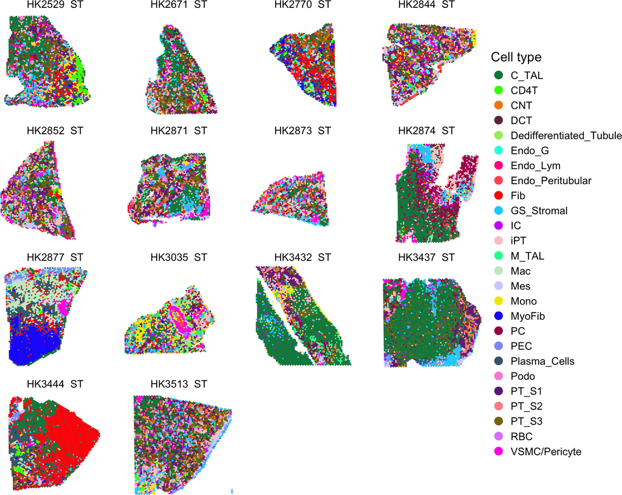

```r
# Extract metadata
plot_df <- as.data.frame(SummarizedExperiment::colData(spe))

# Cell type colors
set.seed(200)
P26 <- Polychrome::createPalette(26, c("#ff0000", "#00ff00", "#0000ff"))
names(P26) <- unique(plot_df$celltype)

# Create the spatial plot
p <- ggplot2::ggplot(
  data = plot_df,
  mapping = ggplot2::aes(x = pxl_col_in_fullres, y = pxl_row_in_fullres, color = celltype)
)
p <- p + ggplot2::geom_point(size = 0.25)
p <- p + ggplot2::scale_colour_manual(name = "Cell type", values = P26)
p <- p + ggplot2::facet_wrap( ~ orig.ident)
p <- p + ggplot2::scale_y_reverse()
p <- p + ggplot2::guides(color = ggplot2::guide_legend(override.aes = list(size = 4), ncol = 1))
p <- p + ggplot2::theme_void()
p <- p + ggplot2::theme(
  panel.background = ggplot2::element_rect(fill = "white", color = NA),
  text = ggplot2::element_text(size = 15),
  plot.title = ggplot2::element_text(hjust = 0.5, face = "bold")
)
p
```

## 5.3 Construct Design Matrix

In this analysis, we account for three primary factors: cell type, experimental condition, and sample identity. Because gene expression patterns often vary across conditions in a cell type-specific manner, our design explicitly models these interactions. This allows us to test for differential expression within specific cell types while simultaneously controlling for sample-level biological and technical variation.

To achieve this, we use an intercept-free, interaction-only design. This formulation treats every combination of condition and cell type as a distinct state, which simplifies the construction of contrasts (e.g., comparing DKD vs. Control within a specific cell type) for hypothesis testing (detailed in the Hypothesis Testing section).

Additionally, we account for sample-specific effects representing the individual-level biological or technical variation. Because each sample belongs to only one experimental condition, we must nest the sample ID within the condition, following a framework similar to the *DESeq2* package (Love et al. 2014) multi-factor approach.

We first map metadata columns to experimental factors and specify reference levels for each. This keeps the design matrix columns in a consistent order, making it much easier to compare specific cell types or conditions during the hypothesis testing step.

```r
# Define covariate columns in metadata
celltype_col <- "celltype"
sample_col <- "orig.ident"
group_col <- "Group"
coord_cols <- c("pxl_row_in_fullres", "pxl_col_in_fullres")
covariates_keep <- c(group_col, celltype_col) # Use when creating design formula

# Define reference levels (baselines) for each factor (celltype, sample, and condition)
ref_celltype <- "C_TAL"
ref_sample <- "HK2874_ST"
ref_group <- "Control"

# Re-level factors to ensure the model uses the correct baseline
SummarizedExperiment::colData(spe)[, sample_col] <- relevel(factor(SummarizedExperiment::colData(spe)[, sample_col]), ref = ref_sample)
SummarizedExperiment::colData(spe)[, celltype_col] <- relevel(factor(SummarizedExperiment::colData(spe)[, celltype_col]), ref = ref_celltype)
SummarizedExperiment::colData(spe)[, group_col] <- relevel(factor(SummarizedExperiment::colData(spe)[, group_col]), ref = ref_group)
```

Multi-sample studies often require controlling for “sample effects” while samples are nested within broader experimental conditions To account for these effects without introducing multi-collinearity, we assign a nested ID (1, 2, 3…) to each sample within its respective condition.

```r
# Extract unique sample IDs for each experimental condition
control_ids <- unique(SummarizedExperiment::colData(spe)[, sample_col][SummarizedExperiment::colData(spe)[, group_col]  == "Control"])
DKD_ids <- unique(SummarizedExperiment::colData(spe)[, sample_col][SummarizedExperiment::colData(spe)[, group_col]  == "DKD"])
HKD_ids <- unique(SummarizedExperiment::colData(spe)[, sample_col][SummarizedExperiment::colData(spe)[, group_col]  == "HKD"])

# Initialize a new ID vector
new_id <- rep(0, nrow(SummarizedExperiment::colData(spe)))

# Assign a numeric index to samples within each condition
for (idx in 1:length(control_ids)) {
  new_id[SummarizedExperiment::colData(spe)[, sample_col] == control_ids[idx]] <- idx
}
for (idx in 1:length(DKD_ids)) {
  new_id[SummarizedExperiment::colData(spe)[, sample_col] == DKD_ids[idx]] <- idx
}
for (idx in 1:length(HKD_ids)) {
  new_id[SummarizedExperiment::colData(spe)[, sample_col] == HKD_ids[idx]] <- idx
}

# Store the nested ID back into the spatial experiment object
SummarizedExperiment::colData(spe)$nested_id <- factor(new_id)
new_nested_sample_col <- "nested_id"
```

The design matrix is constructed using the formula `~ 0 + Group:celltype + Group:nested_id`. The `0 +` term removes the global intercept, allowing the model to estimate absolute means for each interaction term, denoted by the `:` operator.

For example, rather than modeling how the ‘DKD’ condition differs relative to a ‘Control’ baseline, `TESSERA` estimates separate mean for each condition. This approach makes calculating differences between conditions much more intuitive when defining contrasts for hypothesis testing.

```r
# Build the formula string: ~ 0 + Group:celltype + Group:nested_id
design_formula <- as.formula(paste0(" ~ 0 + ",
                                    group_col, ":", celltype_col, " + ",
                                    group_col, ":nested_id"))
print(design_formula)
```

```
> ~0 + Group:celltype + Group:nested_id
```

```r
# Create the design matrix
X_mat <- model.matrix(design_formula, SummarizedExperiment::colData(spe))
```

Raw design matrices often produce messy column names (e.g., GroupDKD:nested_id2). We rename these to reflect the actual sample IDs they represent for better interpretability in downstream analysis.

```r
# Associate each nested ID with its sample and condition
sample_mapping <- colData(spe) %>%
  as.data.frame() %>%
  distinct(pick(all_of(c(group_col, sample_col, "nested_id"))))

# Map nested IDs back to original sample names for clarity
for (i in seq_len(nrow(sample_mapping))) {
  old_name <- paste0(group_col, sample_mapping[[group_col]][i], ":nested_id", sample_mapping$nested_id[i])
  new_name <- paste0(group_col, sample_mapping[[group_col]][i], ":", sample_mapping[[sample_col]][i])
  colnames(X_mat) <- gsub(old_name, new_name, colnames(X_mat), fixed = TRUE)
}
```

We drop zero columns. This removes any columns that represent combinations of factors not present in the data.

```r
# Toss out zero (empty) columns
X_mat <- X_mat[, colSums(X_mat) != 0]
```

We ensure the matrix is of full rank (i.e., that there is no multi-collinearity that would prevent the model from being fitted).

```r
# Ensure the design matrix is full rank
if (Matrix::rankMatrix(X_mat)[1] != ncol(X_mat)) {
  stop("The design matrix is not full rank. Check for linear dependencies.")
}
```

We examine the dimensions of the resulting design matrix, where the rows represent the observations and the columns represent the parameters, $\boldsymbol{\beta}$, to be estimated. It serves as a quick check to ensure the number of model coefficients matches the sum of the numbers of cell type/condition combinations and nested samples.

```r
# Review the design matrix dimensions
dim(X_mat)
```

```
> [1] 37143    88
```

The columns of the final design matrix $X$ represent the specific parameters, $\boldsymbol{\beta}$, to be estimated, with each column name corresponding to a unique cell type, group, or nested sample effect.

```r
# Examine the design matrix column names
head(colnames(X_mat))
```

```
> [1] "GroupControl:celltypeC_TAL" "GroupDKD:celltypeC_TAL"
> [3] "GroupHKD:celltypeC_TAL"     "GroupControl:celltypeCD4T"
> [5] "GroupDKD:celltypeCD4T"      "GroupHKD:celltypeCD4T"
```

## 5.4 Pre-processing Data with `prep_data`

`TESSERA` employs a specialized data format designed to manage multiple samples while respecting the distinct spatial covariance structure inherent to each. A key goal of the preparation step is computational efficiency: we pre-compute quantities that are shared across all genes to drastically reduce the time required for model fitting.

### 5.4.1 The `prep_data` Function

The `prep_data` function acts as a wrapper that converts the input data into the structured format `TESSERA` expects. Data can be provided as either a `SpatialExperiment` object or as raw matrices and data frames.

#### 5.4.1.1 1. Data Input (Choose One)

| Argument | Description |
| --- | --- |
| `x` | A `SpatialExperiment` object. If provided, counts, metadata, and coordinates are extracted automatically. |
| **OR** |  |
| `x` | A variables $\times$ measurements (e.g., genes $\times$ cells) count matrix. Rownames must be variable names. Colnames must be measurement IDs |
| `meta_data` | Data frame of covariates where `rownames(meta_data)` matches `colnames(count_matrix)`. |
| `coord_data` | Coordinates for observations. Required for `spNNGP` or when computing adjacency from scratch. |

#### 5.4.1.2 2. Statistical Design (Choose One)

| Argument | Description |
| --- | --- |
| `design_formula` | A standard R formula object (e.g., `~ 0 + Group:celltype`). |
| `design_mat` | A pre-constructed design matrix. Zero columns will be dropped automatically. |

#### 5.4.1.3 3. Spatial and Model Configuration

| Argument | Description |
| --- | --- |
| `sample_col` | String identifying the column in metadata used to split data by sample. |
| `model_type` | The spatial model to be used: `"Leroux"`, `"CAR"`, `"SAR"`, or `"spNNGP"`; passing in `"ALL"` prepares `TESSERA` for any of the four. |
| `adj_mat` | **(Lattice only)** A pre-computed sparse adjacency matrix. |
| `D_THRESH` | **(Lattice only)** Distance threshold for assigning neighbors. Required if `adj_mat` is not provided. |
| `expected_num_neighbors` | **(Lattice only)** The average neighbors per cell (e.g., 6 for Visium). Used to automate `D_THRESH` calculation; ignored if `D_THRESH` is supplied. |
| `k_search` | **(Lattice only)** The maximum number of neighbors to search for when forming adjacency matrices. |

The data preparation step takes about a minute on an M4 MacBook with 64 GB of RAM. We will load a pre-computed result object for this vignette.

```r
# Output of prepData function
TESSERA_data <- get_my_data("TESSERA_prepData_out.rds")
```

The following code block illustrates the exact code used to perform the data preparation step. The code can be run locally by setting the chunk header to `eval = TRUE`.

```r
t0 <- Sys.time()
# Prepare data for the TESSERA package
TESSERA_data <- TESSERA::prep_data(
  x = spe,
  sample_col = sample_col,
  design_mat = X_mat,
  model_type = "Leroux",
  expected_num_neighbors = 6
)
t1 <- Sys.time()
cat("Preparing data took:",
    round(difftime(t1, t0, units = "mins"), 2), "minutes.\n")
```

The function returns a `TESSERA_data` object: a structured list containing coordinates, covariates, counts, library sizes, and design matrices, all indexed by sample. For lattice models, this object also stores the pre-computed adjacency and degree matrices along with the eigenvalues required to accelerate the model-fitting process. This sample-wise organization ensures that `TESSERA` can efficiently iterate through the data and perform downstream calculations when performing statistical inference.

### 5.4.2 Choosing a Spatial Random Effect Model

The data preparation requirements depend on the spatial random effect model selected. `TESSERA` supports two primary classes of models, which differ in how they define and infer spatial covariance.

#### 5.4.2.1 Lattice Models (Leroux, CAR, SAR)

Lattice models define spatial covariance based on a measurement-measurement adjacency matrix (i.e., identifying which cells are physically adjacent).

- **Model Varieties:**
  - **Leroux** is our preferred default; it decomposes variance into spatially correlated and uncorrelated components and offers the fastest pre-computation.
  - **CAR and SAR** are also supported but are slightly more computationally demanding during the preparation phase.
- **Pre-computation:** These models require a one-time pre-computation of eigenvalues for specific sparse matrices. While this takes a few seconds per sample, it makes the subsequent gene-level model fitting faster.
- **Memory Note:** The pre-computation step computes eigenvalues for an $n \times n$ matrix (where $n$ is the number of cells per sample). For $n < 3000$, this typically uses $< 1$ GB of RAM.

#### 5.4.2.2 Sparse Nearest-Neighbor Gaussian Process (spNNGP) Models

spNNGP models define spatial covariance as a function of pairwise distances between cells using a kernel function (e.g., Matern, Exponential, Gaussian, or Spherical).

- **The “Sparse” Advantage:** The “sparse nearest-neighbor” improvement over a traditional Gaussian process is an approximation that enables greater scalability by discarding the covariance between far-away pairs of cells.
- **No Pre-computation:** spNNGP models do not require adjacency matrices or eigenvalue pre-computation, making the initial preparation faster.
- **Computational Trade-off:** However, the inference process is more intensive and may be slower than lattice models, especially when processing thousands of genes.

### 5.4.3 Defining Adjacency Matrix for Lattice Models

For lattice models, a spatial neighborhood structure must be defined by identifying which cells are physically adjacent. `TESSERA` accepts a pre-computed adjacency matrix for this purpose. However, if the adjacency matrix is unknown, we provide internal utilities to determine cell-cell adjacency based on the data’s spatial coordinates.

For structured grid-based datasets, such as next-generation sequencing datasets from the Visium platform, the `expected_num_neighbors` argument can be specified directly (typically 6 for Visium due to its hexagonal grid). `TESSERA` then automatically determines the distance threshold required to satisfy the target neighbor count, defining any cells within this distance as adjacent. Ultimately, `expected_num_neighbors` serves to automate the discovery of a valid `D_THRESH` argument for structured data, while `D_THRESH` itself offers the manual control required for more complex or non-grid tissue architectures.

In particular, for imaging-based or irregularly-spaced data, determining adjacency is often more nuanced. We provide the `plot_neighbor_distances()` function as a diagnostic tool; it generates boxplots of the distance to the $k$-th nearest neighbor for every cell. A sharp “jump” in distance typically indicates the boundary where cells are no longer physically adjacent. For example, a jump after the sixth neighbor suggests that the seventh closest cell is likely not a direct neighbor.

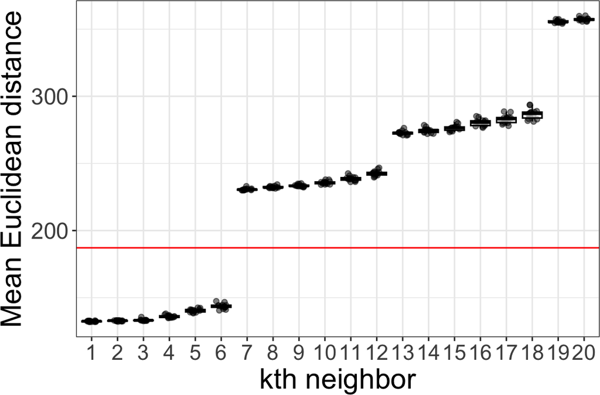

```r
# Inspect distances to identify the neighbor threshold
nb_data <- TESSERA::plot_neighbor_distances(
  meta_data = SummarizedExperiment::colData(spe),
  sample_col = sample_col,
  coord_data = SpatialExperiment::spatialCoords(spe)
)

# Per the plot, we see a jump after the 6th neighbor.
# We use the midpoint of the 6th and 7th neighbor distances as our threshold.
nb_thresh <- mean(colMeans(nb_data$mean_nb_dist[, 6:7]))

p <- nb_data$distances_plot
p <- p + ggplot2::geom_hline(yintercept = nb_thresh, color = "red")
p
```

However, in highly irregular or “noisy” spatial layouts, these plots may become difficult to interpret. In such cases, manual inspection of spatial coordinates or separate processing of associated tissue images, where available, may be necessary to determine a reasonable distance threshold. This value can be passed directly to `prepData()` via the `D_THRESH` argument.

# 6 Model Fitting

## 6.1 Running the ECM Algorithm

`TESSERA` fits models on a single gene at a time. This independence means there is no information sharing between genes during the fitting process and allows for straightforward parallelization across genes.

Model fitting requires three primary inputs: the `TESSERA_data` object generated by `prep_data` (see section Pre-processing Data with `prep_data`), the specific gene name, and the desired covariance structure (e.g., “Leroux”).

`TESSERA` uses an Expectation-Conditional-Maximization (ECM) algorithm to estimate model parameters, structured into an outer and inner loop. Each outer iteration (a full ECM cycle) executes an E-step, followed by an inner loop performing one or more Conditional-Maximization (CM) steps. While the default settings are robust for most spatial transcriptomics datasets, the convergence behavior can be fine-tuned using the following settings:

- **Iteration Limits (outer loop):** `em_iters` sets the maximum number of allowed ECM cycles. `em_min_iters` enforces a minimum number of cycles, ensuring the algorithm moves away from initial values and avoids stopping prematurely on flat regions of the parameter space.
- **Convergence Tolerance (outer loop):** `em_tol` sets the numerical stopping threshold, and `em_stopping` defines the convergence metric used (typically the relative change in log-likelihood). The algorithm terminates when the change between successive full ECM cycles falls below this tolerance.
- **Parameter Updates per E-Step (inner loop):** `opt_iters` controls the number of internal Conditional-Maximization (CM) steps performed per E-step. Increasing this value performs additional parameter updates within each full ECM cycle. Because CM steps are computationally much cheaper than E-steps, performing more CM steps increases the per-cycle runtime but reduces the total number of full ECM cycles needed for convergence.

```r
# Output of TESSERA run with default settings for the "ACTA2" gene
TESSERA_out <- get_my_data("TESSERA_ACTA2_example.rds")
```

The following code block illustrates the exact parameters used to generate the model fitting results for the *ACTA2* gene. The model can be run locally by setting the chunk header to `eval = TRUE`.

```r
# Which gene to run
gene_idx <- which(rownames(spe) == "ACTA2")
# Run TESSERA
TESSERA_out <- TESSERA::TESSERA_lattice(
  # Output of prepData function
  TESSERAData_obj = TESSERA_data,
  # Gene
  gene_name = rownames(spe)[gene_idx],
  # Which covariance structure to use
  model_type = "Leroux",
  # How many ECM iterations to run (maximum)
  em_iters = 200,
  # How many CM steps to run per E-Step
  opt_iters = 5,
  # Min ECM iterations before early stopping
  em_min_iters = 30,
  # Tolerance for early stopping
  em_tol = 1e-3,
  # How to determine early stopping: Relative change in log likelihood
  em_stopping = "rel_loglike",
  # Whether to print out parameter values and convergence information at each iteration
  verbose = FALSE
)

# Output the run-time
print(TESSERA_out$time)
```

Once the algorithm has converged, the output object provides a comprehensive summary of the performance in the `performanceSummary` data frame, allowing for a sample-wise breakdown of the results.

By inspecting the fitted spatial covariance parameters, we can quantify the strength of the spatial dependence for the lattice models via the identifiable parameters `gamma_hat` or `tau2_hat`. While individual spNNGP model parameters are not identifiable, their estimates are provided in the relevant `nugget_hat`, `sill_hat`, `range_hat`, and `smoothness_hat` columns, with `kernel_type` specifying the Gaussian process kernel used.

Model accuracy can be assessed on a per-sample basis using the mean squared error (`MSE_counts_sample`) normalized by the mean squared counts (`Mean_counts2_sample`), yielding a relative MSE for the fitted values.

Finally, among the available Moran’s $I$ metrics, residual Moran’s $I$ (`Moran_residuals`) serves as a critical diagnostic to ensure that the model has successfully captured the spatial structure in the data.

```r
# Inspect a summary of the model fitting results
head(TESSERA_out$performanceSummary, 2)
```

```
>    gene fit_model    sample n_cells gamma_hat  tau2_hat kernel_type nugget_hat
> 1 ACTA2    Leroux HK2529_ST    2970 0.3534340 0.6471708          NA         NA
> 2 ACTA2    Leroux HK2671_ST    2013 0.8875726 1.4297136          NA         NA
>   sill_hat range_hat smoothness_hat MSE_counts_sample MSE_counts_total
> 1       NA        NA             NA          1.344692         1.807373
> 2       NA        NA             NA          1.217016         1.807373
>   Mean_counts2_sample Mean_counts2_total Moran_counts Moran_predictions
> 1            13.60236           56.69332   0.01143411        0.02921505
> 2            45.41083           56.69332   0.04299766        0.05003665
>   Moran_residuals  Moran_phi  Moran_eta Moran_Xbeta Moran_theta
> 1    0.0006048731 0.03196715 0.03449316  0.11150974  0.02106583
> 2   -0.0054987870 0.09087874 0.07396928  0.03187866  0.04924273
>   Moran_librarysize
> 1        0.08424563
> 2        0.09029756
```

The estimated fixed effects are stored in the `beta_hat` field. Each entry corresponds to a column in the design matrix.

```r
# Print fitted parameters
head(TESSERA_out$beta_hat)
```

```
> GroupControl:celltypeC_TAL     GroupDKD:celltypeC_TAL
>                  -7.238039                  -7.045009
>     GroupHKD:celltypeC_TAL  GroupControl:celltypeCD4T
>                  -8.308204                  -6.931760
>      GroupDKD:celltypeCD4T      GroupHKD:celltypeCD4T
>                  -6.871734                  -8.129911
```

## 6.2 Parallelization for Multiple Genes

For the purposes of this vignette, we have already run `TESSERA` on the top 3,000 genes (selected by raw count variance) as described in Section Parallelize via HPC Cluster. The output data frames from each individual gene’s run were row-bound to aggregate the results into a single combined data frame. We load this compiled data frame here to demonstrate downstream analysis and visualization.

```r
# Load pre-computed results for the multi-gene analysis
TESSERA_all <- get_my_data("TESSERA_model_results.rds")
```

The `performance_df` data frame provides a sample-wise breakdown of model performance across the entire dataset. This object follows the same structure as the `performanceSummary` data frame described in the beginning of the Run `TESSERA` section but contains rows for all gene-sample pairs.

```r
# Extract sample-level performance metrics for all 3,000 genes
performance_df <- TESSERA_all$perf_df
```

#### 6.2.0.1 Parallelize via HPC Cluster

`TESSERA` can be run in parallel (or serial) to fit to multiple genes. However, `TESSERA` is computationally intensive if run on hundreds or thousands of genes as is typical for genomic data, so it is best to parallelize this process on a high-performance computing (HPC) cluster.

The following code block illustrates the exact parameterization used to generate our aggregated results used for the remainder of this vignette. To process the full set of 3,000 genes, this model-fitting procedure was executed for each `gene_idx` (1 to 3,000) as independent batch jobs on a high-performance computing (HPC) cluster with the below parameterization.

```r
# Which gene to run
gene_idx <- 1
# Run TESSERA
TESSERA_out <- TESSERA::TESSERA_lattice(
  # Output of prepData function
  TESSERAData_obj = TESSERA_data,
  # Gene
  gene_name = rownames(spe)[gene_idx],
  # Which covariance structure to use
  model_type = "Leroux",
  # How many ECM iterations to run (maximum)
  em_iters = 200,
  # How many CM steps to run per E-Step
  opt_iters = 5,
  # Min ECM iterations before early stopping
  em_min_iters = 30,
  # Tolerance for early stopping
  em_tol = 1e-3,
  # How to determine early stopping: Relative change in log likelihood
  em_stopping = "rel_loglike",
  # Initialization of beta is done via Poisson GLM
  beta_init = "glm",
  # Initialization of gamma is based on the Moran's I of the log-transformed counts
  gamma_init = "moran",
  # Initialization of tau^2 is based on the variance of the log-transformed counts
  tau2_init = "var",
  # Whether to print out parameter values and convergence information at each iteration
  verbose = FALSE
)

# Output the run-time
print(TESSERA_out$time)
```

#### 6.2.0.2 Parallelize via `futures` Package

The following code (not run) shows an example of how to use the `futures` package to parallelize `TESSERA` on 50 genes.

```r
library(future)
library(future.apply)

# How many genes to run
gene_idx_list <- seq(50)
print(length(gene_idx_list))
gene_names <- rownames(spe)[gene_idx_list]

# Setup the backend
n_workers <- min(length(gene_names), parallel::detectCores() - 2)
if (.Platform$OS.type == "unix") {
  future::plan(future::multicore, workers = n_workers)
} else {
  future::plan(future::multisession, workers = n_workers)
}

# Increase memory limit for globals (2GB)
options(future.globals.maxSize = 2000 * 1024^2)

t0 <- Sys.time()

# Run future_lapply
# future.chunk.size = 1 ensures workers don't "batch" these 12-minute tasks.
TESSERA_results <- future.apply::future_lapply(gene_names, function(g_name) {

  TESSERA::TESSERA_lattice(
    TESSERAData_obj = TESSERA_data,
    gene_name       = g_name,
    model_type      = "Leroux",
    em_iters        = 200,
    em_min_iters    = 15,
    em_tol          = 1e-3,
    em_stopping     = "rel_loglike",
    verbose         = FALSE
  )

}, future.seed = TRUE, future.chunk.size = 1)

t1 <- Sys.time()

# Clean up
future::plan(future::sequential)

cat("Parallel processing of", length(gene_names), "genes took:",
    round(difftime(t1, t0, units = "min"), 2), "minutes.\n")
```

# 7 Hypothesis Testing

After fitting models to hundreds or thousands of genes, we aim to identify which among them are differentially expressed. We define differential expression as a statistically significant difference between the entries of the fixed-effect vector, $\boldsymbol{\beta}$, that correspond to distinct experimental groups (e.g., Control vs. DKD within the *VSMC* cell type).

Unlike standard multi-sample methods that often treat observations as independent, `TESSERA` accounts for the inherent spatial correlation between measurements. By explicitly modeling this spatial covariance structure, the method effectively controls the Type I error rate. This prevents the inflation of false positives that commonly occurs when spatial autocorrelation is ignored—a frequent issue in non-spatial models that can lead to misleading biological conclusions.

For a comprehensive discussion of the model’s statistical properties, including power and Type I error benchmarks, please refer to the `TESSERA` methodological manuscript (Constantine et al. 2026).

The results of the hypothesis tests, including specific contrasts, estimated values, associated standard errors, and Wald statistics, are contained in the `wald_df` data frame. Shown below are the results for between-condition comparisons performed within each cell type, a process elaborated upon in the DE Within a Cell Type between Conditions section.

The aggregated results were obtained via the workflow described in Section Parallelize via HPC Cluster.

```r
# Extract Wald test results for all gene-contrast pairs
wald_df <- TESSERA_all$wald_df
head(wald_df, 2)
```

```
>   gene fit_model kernel_type contrast_indices contrast_val contrast_se
> 1  A2M    Leroux          NA              1_2   -0.1190266  0.03726227
> 2  A2M    Leroux          NA              1_3    0.4897356  0.06393596
>   wald_stat_t contrast_description
> 1   -3.194293    C_TAL:Control-DKD
> 2    7.659783    C_TAL:Control-HKD
```

## 7.1 Creating Contrasts

Often, hypothesis testing is accomplished by testing contrasts of an estimated fixed-effects vector. The rows of the contrast matrix correspond to different contrasts, and the columns correspond to the entries of the fixed-effects vector. We assume that each contrast is tested separately and is of the form:
$$\sum_{k = 1}^p c_k \beta_k = 0,$$
where $\beta_k$ is the $k^{th}$ entry of the fixed effects vector $\beta$ and the $c_k$ are coefficients that encode the contrasts.

We illustrate this approach below with two examples of contrast matrices designed to address distinct biological hypotheses: comparing expression across cell types and testing for condition-specific effects within a single cell type. These examples are not exhaustive; the framework is flexible, allowing for the construction of custom contrasts to suit a wide range of research objectives.

### 7.1.1 DE between Cell Types

We demonstrate how to construct a contrast matrix for testing differential expression between two cell types, $c_1$ and $c_2$. The contrasts of interest are
$$\frac{1}{3}\left(\beta_{c_1, \textit{Control}} + \beta_{c_1, \textit{DKD}} + \beta_{c_1, \textit{HKD}}\right) - \frac{1}{3}\left(\beta_{c_2, \textit{Control}} + \beta_{c_2, \textit{DKD}} + \beta_{c_2, \textit{HKD}}\right).$$
First, we extract the cell type levels from the SpatialExperiment object and generate all possible pairwise combinations.

```r
# Get list of cell types from the `SpatialExperiment` object
cell_type_list <- levels(SummarizedExperiment::colData(spe)[, celltype_col])

# Generate all possible pairs of cell types
celltype_pairs <- combn(cell_type_list, 2)
# Column names in design matrix
covariate_names <- colnames(X_mat)
```

We iterate through each pair, identifying the corresponding columns in the design matrix. By assigning weights of $1/3$ (or $1/n$ depending on the number of conditions), we ensure we are testing the difference in average expression across all experimental groups.

```r
# Initialize an empty list to store individual contrast rows
contrast_list <- list()

# Loop over cell type pairs
for (ct_idx in 1:ncol(celltype_pairs)) {
  # Find indices in the design matrix for each cell type in the pair
  idx1 <- which(grepl(celltype_pairs[1, ct_idx], covariate_names))
  idx2 <- which(grepl(celltype_pairs[2, ct_idx], covariate_names))

  # Initialize a single-row matrix with zeros
  tmp <- matrix(data = 0, nrow = 1, ncol = length(covariate_names))

  # Assign weights to represent the average across conditions
  tmp[1, idx1] <- 1 / length(idx1)
  tmp[1, idx2] <- -1 / length(idx2)

  # Name the row for clear identification in the output
  rownames(tmp) <- c(paste0(celltype_pairs[1, ct_idx], "-", celltype_pairs[2, ct_idx]))
  contrast_list[[1 + length(contrast_list)]] <- tmp
}
```

Finally, we bind the individual rows together to create the full contrast matrix.

```r
# Combine the list of rows into a single contrast matrix
celltype_contrast_mat <- Reduce(rbind, contrast_list)
colnames(celltype_contrast_mat) <- covariate_names

# Preview the first few rows and columns
head(celltype_contrast_mat[, 1:6], 2)
```

```
>            GroupControl:celltypeC_TAL GroupDKD:celltypeC_TAL
> C_TAL-CD4T                  0.3333333              0.3333333
> C_TAL-CNT                   0.3333333              0.3333333
>            GroupHKD:celltypeC_TAL GroupControl:celltypeCD4T
> C_TAL-CD4T              0.3333333                -0.3333333
> C_TAL-CNT               0.3333333                 0.0000000
>            GroupDKD:celltypeCD4T GroupHKD:celltypeCD4T
> C_TAL-CD4T            -0.3333333            -0.3333333
> C_TAL-CNT              0.0000000             0.0000000
```

We now view the results of the between-cell type contrasts for the gene *ACTA2* below.

```r
# Compute Wald statistics
one_gene_ct_wald <- TESSERA::calc_Wald_statistics(TESSERA_out, celltype_contrast_mat)
# Remove the raw contrast string for a cleaner display
one_gene_ct_wald <- dplyr::select(one_gene_ct_wald, -c("contrast_string"))
# Preview the first few rows
head(one_gene_ct_wald, 2)
```

```
>             gene fit_model kernel_type contrast_indices contrast_val
> C_TAL-CD4T ACTA2    Leroux          NA      1_2_3_4_5_6   -0.2192822
> C_TAL-CNT  ACTA2    Leroux          NA      1_2_3_7_8_9    0.2746252
>            contrast_se wald_stat_t
> C_TAL-CD4T  0.02851594   -7.689811
> C_TAL-CNT   0.02020265   13.593524
```

### 7.1.2 DE within a Cell Type between Conditions

Beyond comparing cell types, we can construct a contrast matrix to test for differential expression between experimental conditions *within* a specific cell type. For a given cell type $c$, the contrasts of interest are of the following form:
$$\beta_{\textit{c, DKD}} - \beta_{\textit{c, Control}}, \qquad
\beta_{\textit{c, HKD}} - \beta_{\textit{c, Control}}, \qquad
\beta_{\textit{c, HKD}} - \beta_{\textit{c, DKD}}.$$

First, we identify the unique conditions and generate all possible pairwise comparisons.

```r
cell_type_list <- levels(SummarizedExperiment::colData(spe)[, celltype_col])
condition_list <- levels(SummarizedExperiment::colData(spe)[, group_col])

# Generate all pairs of conditions (e.g., Control-DKD, Control-HKD, etc.)
condition_pairs <- combn(condition_list, 2)
# Column names in design matrix
covariate_names <- colnames(X_mat)
```

We iterate through each cell type and, within each, loop through the condition pairs. This identifies the specific entries in the fixed-effect vector $\boldsymbol{\beta}$ that correspond to the intersection of that cell type and those conditions.

```r
# Initialize an empty list to store individual contrast rows
contrast_list <- list()

# Loop over cell types and condition pairs
for (ct in cell_type_list) {
  for (d_idx in 1:ncol(condition_pairs)) {
    # Match the specific column names in the design matrix
    idx1 <- which(covariate_names == paste0(group_col, condition_pairs[1, d_idx], ":", celltype_col, ct))
    idx2 <- which(covariate_names == paste0(group_col, condition_pairs[2, d_idx], ":", celltype_col, ct))

    # Skip the contrast if data is missing for either condition in this cell type
    if ((0 == length(idx1)) || (0 == length(idx2))) {
      next
    }

    # Create the contrast row
    tmp <- matrix(data = 0, nrow = 1, ncol = length(covariate_names))
    tmp[1, idx1] <- 1
    tmp[1, idx2] <- -1

    # Label the row as "Celltype:Condition1-Condition2"
    rownames(tmp) <- c(paste0(ct, ":", condition_pairs[1, d_idx], "-", condition_pairs[2, d_idx]))
    contrast_list[[1 + length(contrast_list)]] <- tmp
  }
}
```

Finally, we bind the individual rows together to create the full contrast matrix.

```r
# Combine the list of rows into a single contrast matrix
contrast_mat <- Reduce(rbind, contrast_list)
colnames(contrast_mat) <- covariate_names

# Preview the first few rows and columns
head(contrast_mat[, 1:5], 2)
```

```
>                   GroupControl:celltypeC_TAL GroupDKD:celltypeC_TAL
> C_TAL:Control-DKD                          1                     -1
> C_TAL:Control-HKD                          1                      0
>                   GroupHKD:celltypeC_TAL GroupControl:celltypeCD4T
> C_TAL:Control-DKD                      0                         0
> C_TAL:Control-HKD                     -1                         0
>                   GroupDKD:celltypeCD4T
> C_TAL:Control-DKD                     0
> C_TAL:Control-HKD                     0
```

We now view the results of the between-conditions within-cell type contrasts for the gene *ACTA2* below.

```r
# Compute Wald statistics
one_gene_wald <- TESSERA::calc_Wald_statistics(TESSERA_out, contrast_mat)
# Remove the raw contrast string for a cleaner display
one_gene_wald <- dplyr::select(one_gene_wald, -c("contrast_string"))
# Preview the first few rows
head(one_gene_wald, 2)
```

```
>                    gene fit_model kernel_type contrast_indices contrast_val
> C_TAL:Control-DKD ACTA2    Leroux          NA              1_2   -0.1930309
> C_TAL:Control-HKD ACTA2    Leroux          NA              1_3    1.0701649
>                   contrast_se wald_stat_t
> C_TAL:Control-DKD  0.08324288   -2.318888
> C_TAL:Control-HKD  0.13379417    7.998591
```

We can inspect the data frame created in the aggregation script, from running `TESSERA` on the top 3,000 genes.

```r
# Filter and preview the aggregated multi-gene results
wald_df <- wald_df[!is.na(wald_df$wald_stat_t), ]
head(wald_df, 2)
```

```
>   gene fit_model kernel_type contrast_indices contrast_val contrast_se
> 1  A2M    Leroux          NA              1_2   -0.1190266  0.03726227
> 2  A2M    Leroux          NA              1_3    0.4897356  0.06393596
>   wald_stat_t contrast_description
> 1   -3.194293    C_TAL:Control-DKD
> 2    7.659783    C_TAL:Control-HKD
```

## 7.2 Empirical Null Distribution Estimation

For a generalized linear mixed model (GLMM), such as the one implemented in `TESSERA`, the null distribution of Wald test statistics is typically not known. With a sufficient number of samples (meaning, independent experimental units, not individual cells), it will approach a normal distribution or a $\chi_1^2$ distribution (depending on if the statistics are squared). However, in the finite-sample regime, GLMMs are prone to bias in both the coefficients and their associated standard errors. Even with many samples, this bias can shift the null distribution away from theoretical expectations, necessitating an empirical estimation approach.

If we are testing hundreds or thousands of genes, there is a path forward: we can use Efron’s idea of estimating the null distribution directly from the data (Efron 2004). In our case, we believe that the square of the Wald statistics computed previously can be modeled as a scaled, non-central $\chi_1^2$ distribution. The functions below may be used to find optimal parameter estimates for this distribution. Essentially, we look for a threshold below which most of the statistics come from the null distribution; for these statistics, the $p$-values should look uniformly distributed on $(0, 1)$.

In general, empirical null distribution estimation procedures rely on having sufficient statistics that come from the null distribution, as otherwise, there will not be enough data to reliably estimate a distribution, or the statistics used to estimate the distribution will not be from the null distribution. Moreover, having more than one contrast (of a similar nature, e.g., DE within a cell type) strengthens the procedure by providing more data and capturing a wider range of variability.

The analysis in this section, and the resulting `wald_df`, focuses exclusively on the between-condition comparisons within each cell type. The empirical null distribution described here is derived solely from these specific contrasts.

For this vignette, we have already performed the thresholding procedure using these between-condition within-cell type contrasts. We load the resulting object below to demonstrate the downstream analysis.

```r
# Output of applying TESSERA's empirical null thresholding procedure
wald_thresh_selection <- get_my_data("TESSERA_wald_threshold_out.rds")
```

To execute the full procedure, the following code can be used by setting `eval = TRUE` in the code chunk header. Please note that the estimated runtime is approximately 3.5 minutes on an M4 MacBook with 64 GB of RAM.

```r
t0 <- Sys.time()
# Empirical Null Estimation
# Sweep over thresholds to find the optimal distribution parameters for the empirical null
wald_thresh_selection <- TESSERA::select_Wald_threshold(
  wald_stats = wald_df$wald_stat_t^2,
  quantile_spacing = 0.01,
  metric = "Raw_MSE"
)
t1 <- Sys.time()
cat("Threshold selection of", nrow(wald_df), "statistics took:",
    round(difftime(t1, t0, units = "mins"), 2), "minutes.\n")
```

We can inspect the estimated scale and shift parameters for the fitted scaled, non-central $\chi_1^2$ null distribution.

```r
# View the estimated parameters for the scaled, non-central chi-squared distribution
wald_thresh_selection$chi2_params
```

```
>        scale        shift
> 2.328768e+01 9.217872e-07
```

Next, we view the selected Wald statistic threshold.

```r
# View the selected Wald statistic threshold
wald_thresh_selection$threshold
```

```
> [1] 119.2417
```

## 7.3 Obtaining $p$-Values

Once the empirical null distribution is fit, we can calculate $p$-values and perform hypothesis testing for differential expression, in this case, between conditions within a cell type.

### 7.3.1 `TESSERA` $p$-values

We compute the $p$-values and apply the Benjamini-Hochberg (BH) adjustment over genes within each contrast to control the False Discovery Rate (FDR) at a level of 0.05.

```r
# FDR level
PVAL_THRESH <- 0.05

# Compute p-values using the estimated empirical null distribution
wald_df$wald_pval <- TESSERA::calc_scaled_noncentral_chi2_pvalues(wald_stats = wald_df$wald_stat_t^2,
                                                                  chi2_params = wald_thresh_selection$chi2_params)
# Adjust p-values for multiple testing per contrast
for (cd in unique(wald_df$contrast_description)) {
  wald_df$wald_pval_adj[wald_df$contrast_description == cd] <- p.adjust(wald_df$wald_pval[wald_df$contrast_description == cd], method = "BH")
}
```

We summarize the results by looking at the number of significant genes for each comparison. As a sanity check, we see that cell types with very few cells in the dataset, such as RBC (red blood cells), find the fewest number of DE genes.

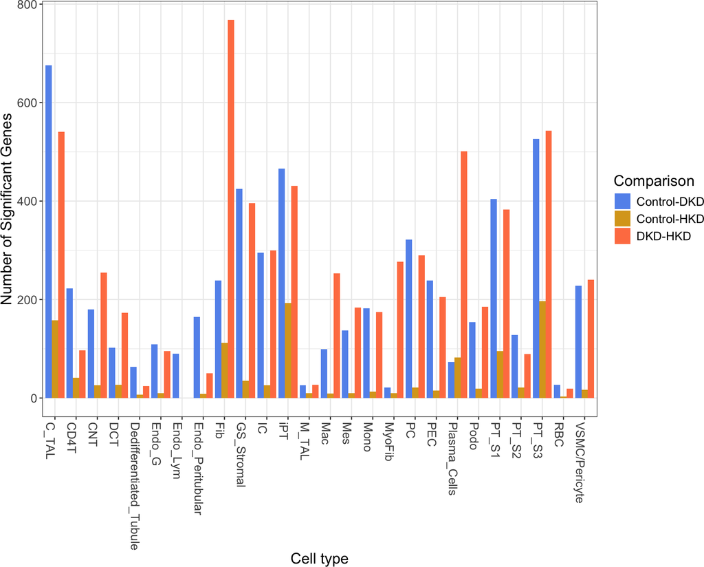

```r
n_sig_df <- data.frame(wald_df
                       %>% dplyr::group_by(contrast_description)
                       %>% dplyr::summarise(n_sig = sum(wald_pval_adj < PVAL_THRESH, na.rm = TRUE)))
n_sig_df$celltype <- sapply(n_sig_df$contrast_description, function (x) {strsplit(x, ":")[[1]][1]})
n_sig_df$comparison <- sapply(n_sig_df$contrast_description, function (x) {strsplit(x, ":")[[1]][2]})

p <- ggplot2::ggplot(data = n_sig_df, mapping = ggplot2::aes(x = celltype, y = n_sig, fill = comparison))
p <- p + ggplot2::geom_col(position = ggplot2::position_dodge(preserve = "single"))
p <- p + ggplot2::scale_fill_manual(values = c("cornflowerblue", "goldenrod", "coral"))
p <- p + ggplot2::labs(x = "Cell type",
                       y = "Number of Significant Genes",
                       fill = "Comparison")
p <- p + ggplot2::theme_bw()
p <- p + ggplot2::theme(axis.text.x = ggplot2::element_text(angle = -90, hjust = 0))
p <- p + ggplot2::theme(text = ggplot2::element_text(size = 15))
p
```

### 7.3.2 `fdrtool` $p$-values

Another empirical null distribution estimation procedure to obtain $p$-values is the False Non-Discovery Rate (FNDR) method from the *fdrtool* package (Strimmer 2008). While both empirical null estimation procedures can be used to generate $p$-values, there are key trade-offs to consider: `fdrtool` offers a faster runtime than `TESSERA`’s thresholding procedure, but `TESSERA` makes fewer underlying assumptions about the data distribution. Both methods achieve highly comparable performance on this class of spatial transcriptomics data as can be seen in the `TESSERA` methodological manuscript (Constantine et al. 2026).

```r
# Estimate p-values using fdrtool's FNDR method
fndr_out <- fdrtool::fdrtool(wald_df$wald_stat_t,
                             cutoff.method = "fndr",
                             plot = FALSE)
```

```
> Step 1... determine cutoff point
> Step 2... estimate parameters of null distribution and eta0
> Step 3... compute p-values and estimate empirical PDF/CDF
> Step 4... compute q-values and local fdr
```

```r
# Store fdrtool p-values
wald_df$wald_pval_fndr <- fndr_out$pval

# Adjust fdrtool p-values for multiple testing
wald_df$wald_pval_adj_fndr <- NA
for (cd in unique(wald_df$contrast_description)) {
  wald_df$wald_pval_adj_fndr[wald_df$contrast_description == cd] <- p.adjust(wald_df$wald_pval_fndr[wald_df$contrast_description == cd], method = "BH")
}
```

# References

Abedini, Amin, Jonathan Levinsohn, Konstantin A. Klötzer, et al. 2024. “Single-Cell Multi-Omic and Spatial Profiling of Human Kidneys Implicates the Fibrotic Microenvironment in Kidney Disease Progression.” *Nature Genetics* 56 (8): 1712–24. https://doi.org/10.1038/s41588-024-01802-x.

Constantine, Florica J., Zoltan Lasik, Sandrine Dudoit, and Elizabeth Purdom. 2026. “Unlocking Multi-Sample Differential Expression for Spatial Transcriptomics Data with TESSERA.” *bioRxiv*.

Efron, Bradley. 2004. “Large-Scale Simultaneous Hypothesis Testing: The Choice of a Null Hypothesis.” *Journal of the American Statistical Association* 99 (465): 96–104. https://doi.org/10.1198/016214504000000089.

Love, Michael I, Wolfgang Huber, and Simon Anders. 2014. “Moderated Estimation of Fold Change and Dispersion for RNA-Seq Data with DESeq2.” *Genome Biology* 15 (12): 550. https://doi.org/10.1186/s13059-014-0550-8.

Strimmer, Korbinian. 2008. “Fdrtool: A Versatile r Package for Estimating Local and Tail Area-Based False Discovery Rates.” *Bioinformatics* 24 (12): 1461–62. https://doi.org/10.1093/bioinformatics/btn209.